# Упражнение № 7

Спиридонова Алина

10 04 2021

Необходимо построить две модели:

- зависимости непрерывного отклика от одного непрерывного предиктора;
- зависимости вероятности (логит) от одного непрерывного предиктора.

Для каждой модели:

1 Указать смысл переменных модели, метод оценки и настроечный параметр (степень полинома, гиперпараметр λ, ширина окна s, число узлов – в зависимости от метода).

2 Подогнать модель на всех наблюдениях, меняя значение настроечного параметра.

3 Обосновать оптимальное значение настроечного параметра подходящим методом (кросс-валидация, ANOVA).

4 Сделать прогноз на обучающую выборку по лучшей модели: модельные значения и ошибки прогноза.

5 Построить график с фактическими наблюдениями, модельной кривой и 95% доверительными интервалами прогноза.

В таблице ниже указаны набор данных, столбцы с переменными для модели и метод подгонки.

## Вариант № 24 (6)

Модели: Полиномиальный сплайн.

Данные: *Boston {MASS}*.

Работаем с набором данных по стоимости жилья в пригороде Бостона. Присоединяем его к пространству имён функцией attach(), и дальше обращаемся напрямую к столбцам таблицы.

```r
# загрузка данных Boston
data('Boston')

# ядро
my.seed <- 6
attach(Boston)
```

Работаем со столбцами:

- *indus* – доля нерозничных торговых площадей на город;
- *nox* – концентрация оксидов азота (частей на 10 млн.)

# Полиномиальный сплайн

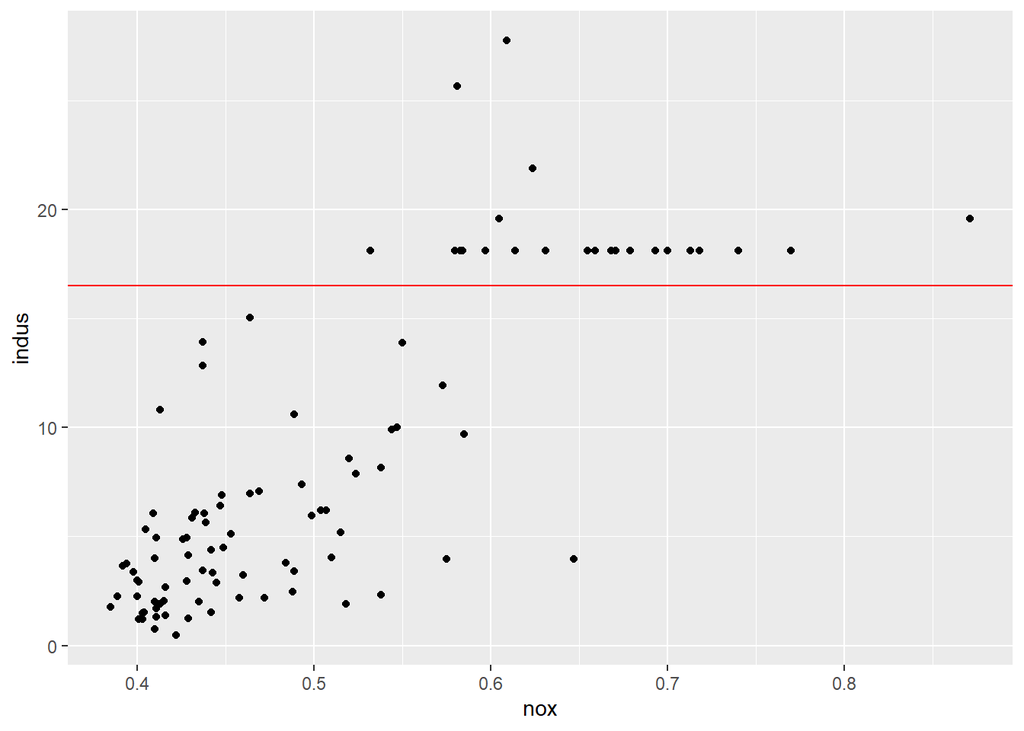

```r
gp <- ggplot(data = Boston, aes(x = nox, y = indus))
gp <- gp + geom_point() + geom_abline(slope = 0, intercept = 16.5, col = 'red')
gp
```

## Сплайны

```r
# границы изменения переменной nox
noxlims <- range(nox)

# значения nox, для которых делаем прогноз (от min до max с шагом 1)
nox.grid <- seq(from = noxlims[1], to = noxlims[2], length = 100)

# кубический сплайн с тремя узлами
fit <- lm(indus ~ bs(nox, knots = c(25, 40, 60)), data = Boston)
# прогноз
preds.spl <- predict(fit, newdata = list(nox = nox.grid), se = T)
```

Теперь построим натуральный по трём узлам. Три узла это 6 степеней свободы. Если функции bs(), которая создаёт матрицу с базисом для полиномиального сплайна, передать только степени свободы, она распределит узлы равномерно. В данном случае это квартили распределения *nox*.

```r
# 3 узла -- 6 степеней свободы (столбцы матрицы)
dim(bs(nox, knots = c(25, 40, 60)))
```

```
## [1] 506   6
```

```r
# если не указываем узлы явно...
dim(bs(nox, df = 6))
```

```
## [1] 506   6
```

```r
#  они привязываются к квартилям
attr(bs(nox, df = 6), 'knots')
```

```
##   25%   50%   75%
## 0.449 0.538 0.624
```

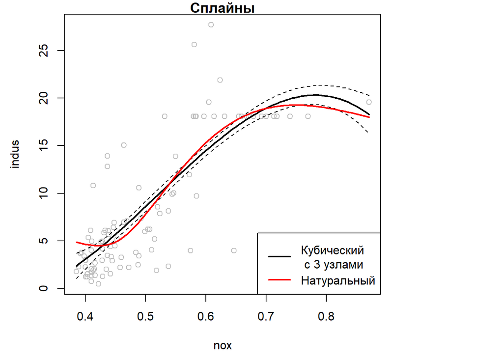

```r
# натуральный сплайн
fit2 <- lm(indus ~ ns(nox, df = 4), data = Boston)

preds.spl2 <- predict(fit2, newdata = list(nox = nox.grid), se = T)

#График сравнения кубического и натурального сплайнов.

par(mfrow = c(1, 1), mar = c(4.5, 4.5, 1, 8.5), oma = c(0, 0, 0, 0), xpd = T)

# наблюдения
plot(nox, indus, col = 'grey')

# модель кубического сплайна
lines(nox.grid, preds.spl$fit, lwd = 2)

# доверительный интервал
lines(nox.grid, preds.spl$fit + 2*preds.spl$se, lty = 'dashed')
lines(nox.grid, preds.spl$fit - 2*preds.spl$se, lty = 'dashed')

# натуральный сплайн
lines(nox.grid, preds.spl2$fit, col = 'red', lwd = 2)

# легенда
legend("bottomright", inset = c(0, 0),
       c('Кубический \n с 3 узлами', 'Натуральный'),
       lwd = rep(2, 2), col = c('black', 'red'))

# заголовок
title("Сплайны")
```

```r
fit <- lm(indus ~ poly(nox, 3), data = Boston)
round(coef(summary(fit)), 2)
```

```
##               Estimate Std. Error t value Pr(>|t|)
## (Intercept)      11.14       0.18   60.34        0
## poly(nox, 3)1   117.73       4.15   28.36        0
## poly(nox, 3)2   -32.47       4.15   -7.82        0
## poly(nox, 3)3   -14.12       4.15   -3.40        0
```

Функция poly(nox, 3) создаёт таблицу с базисом ортогональных полиномов: линейные комбинации значений переменной nox в степенях от 1 до 3.

```r
round(head(poly(nox, 3)), 3)
```

```
##           1      2     3
## [1,] -0.006 -0.033 0.040
## [2,] -0.033  0.003 0.028
## [3,] -0.033  0.003 0.028
## [4,] -0.037  0.011 0.019
## [5,] -0.037  0.011 0.019
## [6,] -0.037  0.011 0.019
```

можно получить сами значения nox в заданных степенях

```r
round(head(poly(nox, 3, raw = T)), 3)
```

```
##          1     2     3
## [1,] 0.538 0.289 0.156
## [2,] 0.469 0.220 0.103
## [3,] 0.469 0.220 0.103
## [4,] 0.458 0.210 0.096
## [5,] 0.458 0.210 0.096
## [6,] 0.458 0.210 0.096
```

```r
# на прогноз не повлияет, но оценки параметров изменяются
fit.2 <- lm(indus ~ poly(nox, 3, raw = T), data = Boston)
round(coef(summary(fit.2)), 2)
```

```
##                        Estimate Std. Error t value Pr(>|t|)
## (Intercept)               19.14      19.31    0.99     0.32
## poly(nox, 3, raw = T)1  -175.03      97.80   -1.79     0.07
## poly(nox, 3, raw = T)2   453.56     160.65    2.82     0.00
## poly(nox, 3, raw = T)3  -291.31      85.68   -3.40     0.00
```

```r
# границы изменения переменной nox
noxlims <- range(nox)

# значения nox, для которых делаем прогноз (от min до max с шагом 1)
nox.grid <- seq(from = noxlims[1], to = noxlims[2], length = 100)

# рассчитать прогнозы и их стандартные ошибки
preds <- predict(fit, newdata = list(nox = nox.grid), se = T)

# границы доверительного интервала для заработной платы
se.bands <- cbind(lower.bound = preds$fit - 2*preds$se.fit,
                  upper.bound = preds$fit + 2*preds$se.fit)

# смотрим результат
round(head(se.bands), 2)
```

```
##   lower.bound upper.bound
## 1        1.02        3.69
## 2        1.35        3.81
## 3        1.67        3.93
## 4        2.00        4.07
## 5        2.32        4.23
## 6        2.64        4.39
```

Убедимся, что прогнозы по моделям с различными вызовами poly() совпадают и подбираем степень полинома, сравнивая модели со степенями от 1 до 5 с помощью дисперсионного анализа (ANOVA)

```r
# прогнозы по второму вызову модели
preds2 <- predict(fit.2, newdata = list(nox = nox.grid), se = T)

# максимальное расхождение между прогнозами по двум вариантам вызова модели
max(abs(preds$fit - preds2$fit))
```

```
## [1] 3.943512e-13
```

```r
fit.1 <- lm(indus ~ nox, data = Boston)
fit.2 <- lm(indus ~ poly(nox, 2), data = Boston)
fit.3 <- lm(indus ~ poly(nox, 3), data = Boston)
fit.4 <- lm(indus ~ poly(nox, 4), data = Boston)
fit.5 <- lm(indus ~ poly(nox, 5), data = Boston)

round(anova(fit.1, fit.2, fit.3, fit.4, fit.5), 2)
```

```
## Analysis of Variance Table
##
## Model 1: indus ~ nox
## Model 2: indus ~ poly(nox, 2)
## Model 3: indus ~ poly(nox, 3)
## Model 4: indus ~ poly(nox, 4)
## Model 5: indus ~ poly(nox, 5)
##   Res.Df    RSS Df Sum of Sq     F Pr(>F)
## 1    504 9907.2
## 2    503 8852.8  1   1054.42 66.64 <2e-16 ***
## 3    502 8653.5  1    199.25 12.59 <2e-16 ***
## 4    501 8021.7  1    631.82 39.93 <2e-16 ***
## 5    500 7911.2  1    110.49  6.98   0.01 **
## ---
## Signif. codes:  0 '***' 0.001 '**' 0.01 '*' 0.05 '.' 0.1 ' ' 1
```

```r
# Лучшая модель
best.fit.1 <- fit.4
```

Прогноз на обучающую выборку по лучшей модели (модель 1)

```r
# прогноз по лучшей модели
preds <- predict(best.fit.1, data.frame(nox = nox.grid), se = T)

# границы доверительного интервала для площади нерозничных торговых площадей
se.bands <- cbind(lower.bound = preds$fit - 2*preds$se.fit,
                  upper.bound = preds$fit + 2*preds$se.fit)

# смотрим результат
round(head(se.bands), 2)
```

```
##   lower.bound upper.bound
## 1        4.57        8.21
## 2        4.30        7.48
## 3        4.08        6.84
## 4        3.90        6.30
## 5        3.77        5.84
## 6        3.67        5.48
```

```r
# Стандартные ошибки
round(preds$se.fit, 2)
```

```
##    1    2    3    4    5    6    7    8    9   10   11   12   13   14   15   16
## 0.91 0.79 0.69 0.60 0.52 0.45 0.40 0.36 0.33 0.31 0.30 0.30 0.30 0.30 0.31 0.31
##   17   18   19   20   21   22   23   24   25   26   27   28   29   30   31   32
## 0.31 0.32 0.32 0.31 0.31 0.31 0.30 0.30 0.29 0.29 0.29 0.28 0.28 0.28 0.27 0.28
##   33   34   35   36   37   38   39   40   41   42   43   44   45   46   47   48
## 0.28 0.28 0.28 0.29 0.29 0.30 0.30 0.31 0.32 0.32 0.33 0.33 0.34 0.34 0.34 0.34
##   49   50   51   52   53   54   55   56   57   58   59   60   61   62   63   64
## 0.34 0.34 0.34 0.34 0.34 0.34 0.34 0.33 0.33 0.33 0.33 0.34 0.34 0.35 0.36 0.37
##   65   66   67   68   69   70   71   72   73   74   75   76   77   78   79   80
## 0.38 0.39 0.41 0.43 0.45 0.47 0.49 0.52 0.54 0.56 0.59 0.61 0.63 0.66 0.68 0.70
##   81   82   83   84   85   86   87   88   89   90   91   92   93   94   95   96
## 0.71 0.73 0.74 0.75 0.76 0.77 0.78 0.78 0.78 0.78 0.78 0.78 0.78 0.78 0.79 0.81
##   97   98   99  100
## 0.83 0.87 0.93 1.00
```

## График с фактическими наблюдениями, модельной кривой и 95% доверительными интервалами прогноза (модель 1)

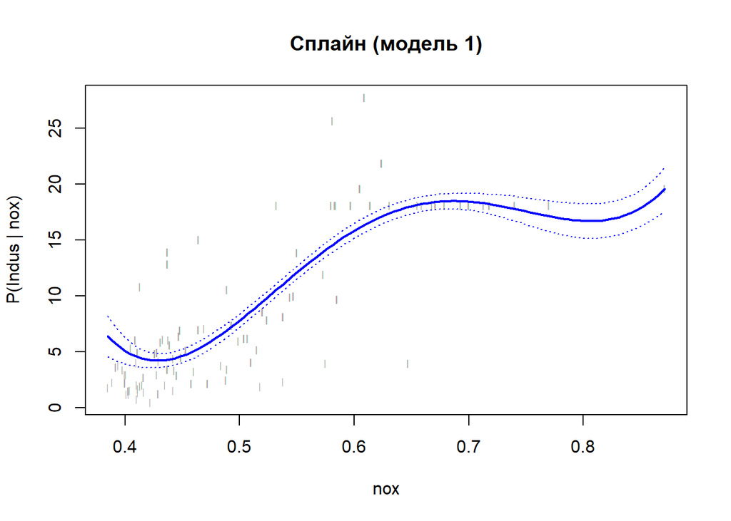

```r
# сетка для графика
plot(nox, indus, xlim = noxlims, type = 'n', ylab = 'P(Indus | nox)')

# фактические наблюдения показываем засечками
points(jitter(nox), indus, cex = 0.5, pch = '|', col = 'darkgrey')

pfit <- preds$fit

# модель
lines(nox.grid, pfit, lwd = 2, col = 'blue')

# доверительные интервалы
matlines(nox.grid, se.bands, lwd = 1, col = 'blue', lty = 3)

# заголовок
title('Сплайн (модель 1)')
```

Зависимость вероятности доли торговых площадей > 16.5 от конценрации оксида азота (модель 2)

[figure not shown]

```r
# график
plot(nox, I(indus > 16.5), xlim = noxlims, cex = 0.5, col = 'darkgrey', ylim = c(-0.1, 1.15))

# подгоняем модель c окном 0.2
fit3 <- loess(I(indus > 16.5) ~ nox, cv = 0.2, data = Boston)

# подгоняем модель c окном 0.7
fit4 <- loess(I(indus > 16.5) ~ nox, span = 0.7, data = Boston)

# рисум модели
lines(nox.grid, predict(fit3, data.frame(nox = nox.grid)),
      col = 'red', lwd = 2)
lines(nox.grid, predict(fit4, data.frame(nox = nox.grid)),
      col = 'blue', lwd = 2)

# легенда ,inset = c(0.5, 1)
legend("bottomright",
       c('Кубический \n с 3 узлами', 'Натуральный'),
       lwd = rep(2, 2), col = c('black', 'red'))

title('Сплайн')
```

## Определение оптимального настроечного параметра (модель 2)

```r
fit <- lm(indus ~ poly(nox, 3), data = Boston)
round(coef(summary(fit)), 2)
```

```
##               Estimate Std. Error t value Pr(>|t|)
## (Intercept)      11.14       0.18   60.34        0
## poly(nox, 3)1   117.73       4.15   28.36        0
## poly(nox, 3)2   -32.47       4.15   -7.82        0
## poly(nox, 3)3   -14.12       4.15   -3.40        0
```

```r
round(head(poly(nox, 3)), 3)
```

```
##           1      2     3
## [1,] -0.006 -0.033 0.040
## [2,] -0.033  0.003 0.028
## [3,] -0.033  0.003 0.028
## [4,] -0.037  0.011 0.019
## [5,] -0.037  0.011 0.019
## [6,] -0.037  0.011 0.019
```

```r
round(head(poly(nox, 3, raw = T)), 3)
```

```
##          1     2     3
## [1,] 0.538 0.289 0.156
## [2,] 0.469 0.220 0.103
## [3,] 0.469 0.220 0.103
## [4,] 0.458 0.210 0.096
## [5,] 0.458 0.210 0.096
## [6,] 0.458 0.210 0.096
```

```r
# на прогноз не повлияет, но оценки параметров изменяются
fit.2 <- lm(indus ~ poly(nox, 3, raw = T), data = Boston)
round(coef(summary(fit.2)), 2)
```

```
##                        Estimate Std. Error t value Pr(>|t|)
## (Intercept)               19.14      19.31    0.99     0.32
## poly(nox, 3, raw = T)1  -175.03      97.80   -1.79     0.07
## poly(nox, 3, raw = T)2   453.56     160.65    2.82     0.00
## poly(nox, 3, raw = T)3  -291.31      85.68   -3.40     0.00
```

```r
# границы изменения переменной nox
noxlims <- range(nox)

# значения nox, для которых делаем прогноз (от min до max с шагом 1)
nox.grid <- seq(from = noxlims[1], to = noxlims[2], length = 100)

# рассчитать прогнозы и их стандартные ошибки
preds <- predict(fit, newdata = list(nox = nox.grid), se = T)

# границы доверительного интервала для заработной платы
se.bands <- cbind(lower.bound = preds$fit - 2*preds$se.fit,
                  upper.bound = preds$fit + 2*preds$se.fit)

# смотрим результат
round(head(se.bands), 2)
```

```
##   lower.bound upper.bound
## 1        1.02        3.69
## 2        1.35        3.81
## 3        1.67        3.93
## 4        2.00        4.07
## 5        2.32        4.23
## 6        2.64        4.39
```

Убедимся, что прогнозы по моделям с различными вызовами poly() совпадают и подбираем степень полинома, сравнивая модели со степенями от 1 до 5 с помощью дисперсионного анализа (ANOVA)

```r
# прогнозы по второму вызову модели
preds2 <- predict(fit.2, newdata = list(nox = nox.grid), se = T)

# максимальное расхождение между прогнозами по двум вариантам вызова модели
max(abs(preds$fit - preds2$fit))
```

```
## [1] 3.943512e-13
```

```r
fit.1 <- lm(I(indus>16.5) ~ nox, data = Boston)
fit.2 <- lm(I(indus>16.5) ~ poly(nox, 2), data = Boston)
fit.3 <- lm(I(indus>16.5) ~ poly(nox, 3), data = Boston)
fit.4 <- lm(I(indus>16.5) ~ poly(nox, 4), data = Boston)
fit.5 <- lm(I(indus>16.5) ~ poly(nox, 5), data = Boston)

round(anova(fit.1, fit.2, fit.3, fit.4, fit.5), 2)
```

```
## Analysis of Variance Table
##
## Model 1: I(indus > 16.5) ~ nox
## Model 2: I(indus > 16.5) ~ poly(nox, 2)
## Model 3: I(indus > 16.5) ~ poly(nox, 3)
## Model 4: I(indus > 16.5) ~ poly(nox, 4)
## Model 5: I(indus > 16.5) ~ poly(nox, 5)
##   Res.Df   RSS Df Sum of Sq      F    Pr(>F)
## 1    504 41.75
## 2    503 40.44  1      1.31  22.78 < 2.2e-16 ***
## 3    502 32.40  1      8.04 139.88 < 2.2e-16 ***
## 4    501 29.83  1      2.57  44.71 < 2.2e-16 ***
## 5    500 28.72  1      1.11  19.37 < 2.2e-16 ***
## ---
## Signif. codes:  0 '***' 0.001 '**' 0.01 '*' 0.05 '.' 0.1 ' ' 1
```

```r
# Лучшая модель
best.fit.2 <- fit.4
```

## Прогноз на обучающую выборку по лучшей модели (модель 2)

```r
# Прогноз по лучшей модели
preds <- predict(best.fit.2, data.frame(nox = nox.grid), se = T)

# Границы доверительного интервала для площади нерозничных торговых площадей
se.bands <- cbind(lower.bound = preds$fit - 2*preds$se.fit,
                  upper.bound = preds$fit + 2*preds$se.fit)

# Смотрим результат
round(head(se.bands), 2)
```

```
##   lower.bound upper.bound
## 1        0.17        0.40
## 2        0.13        0.32
## 3        0.09        0.25
## 4        0.05        0.19
## 5        0.02        0.14
## 6       -0.01        0.10
```

```r
# Стандартные ошибки
round(preds$se.fit, 2)
```

```
##    1    2    3    4    5    6    7    8    9   10   11   12   13   14   15   16
## 0.06 0.05 0.04 0.04 0.03 0.03 0.02 0.02 0.02 0.02 0.02 0.02 0.02 0.02 0.02 0.02
##   17   18   19   20   21   22   23   24   25   26   27   28   29   30   31   32
## 0.02 0.02 0.02 0.02 0.02 0.02 0.02 0.02 0.02 0.02 0.02 0.02 0.02 0.02 0.02 0.02
##   33   34   35   36   37   38   39   40   41   42   43   44   45   46   47   48
## 0.02 0.02 0.02 0.02 0.02 0.02 0.02 0.02 0.02 0.02 0.02 0.02 0.02 0.02 0.02 0.02
##   49   50   51   52   53   54   55   56   57   58   59   60   61   62   63   64
## 0.02 0.02 0.02 0.02 0.02 0.02 0.02 0.02 0.02 0.02 0.02 0.02 0.02 0.02 0.02 0.02
##   65   66   67   68   69   70   71   72   73   74   75   76   77   78   79   80
## 0.02 0.02 0.03 0.03 0.03 0.03 0.03 0.03 0.03 0.03 0.04 0.04 0.04 0.04 0.04 0.04
##   81   82   83   84   85   86   87   88   89   90   91   92   93   94   95   96
## 0.04 0.04 0.05 0.05 0.05 0.05 0.05 0.05 0.05 0.05 0.05 0.05 0.05 0.05 0.05 0.05
##   97   98   99  100
## 0.05 0.05 0.06 0.06
```

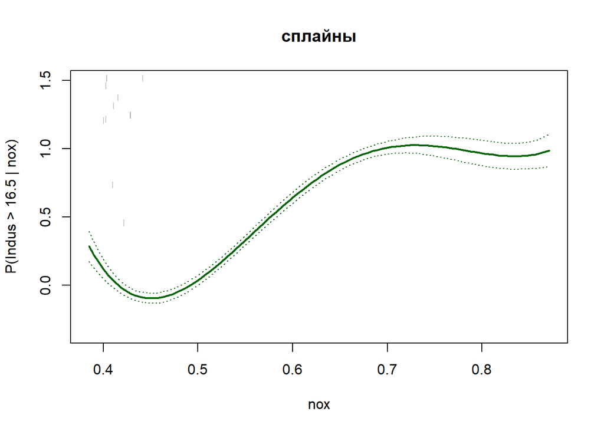

```r
# Сетка для графика
plot(nox, I(indus > 16.5), xlim = noxlims, type = 'n', ylim = c(-0.35, 1.5),
     ylab = 'P(Indus > 16.5 | nox)')

# Фактические наблюдения показываем засечки
points(jitter(nox), indus, cex = 0.5, pch = '|', col = 'darkgrey')

pfit <- preds$fit
# Модель
lines(nox.grid, pfit, lwd = 2, col = 'darkgreen')

# Доверительные интервалы
matlines(nox.grid, se.bands, lwd = 1, col = 'darkgreen', lty = 3)

# Заголовок
title('сплайны')
```